# CA5 Phase1

The goal of this assignment is to implement a neural network and use it to classifiy given images of handwritten digits. Also, we analyse impact of different hyper parameters such as activaton functions, learning rate and batch size on the accuracy of the implemented network.

## Dataset

# Phase 1

```python
from sklearn.model_selection import train_test_split
import pickle
import time
import random
from PIL import Image
import matplotlib
import matplotlib.pyplot as plt
import numpy as np
from sklearn.preprocessing import OneHotEncoder
import numpy
import time
from scipy.special import softmax
```

```python
pkl_file = open('dataset/data.pkl','rb')
data = pickle.load(pkl_file)
pkl_file = open('dataset/labels.pkl','rb')
labels = pickle.load(pkl_file)

train_data, test_data, train_labels, test_labels = train_test_split(data, labels, test_size=0.2, shuffle=True, random_state=1,stratify=labels)
```

## 1. show sample

```
Label:  6
```

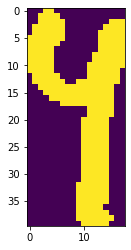

```python
def print_img(label, img):
    print("Label: ", label)
    plt.imshow(img)
    plt.show()

random_num = random.randint(0, len(train_data))

print_img(train_labels[random_num], train_data[random_num])
```

Each pixel is either 0 or 255

```python
#print(train_data[2])
(unique, counts) = np.unique(train_data[random_num], return_counts=True)
frequencies = np.asarray((unique, counts)).T
print(frequencies)
```

```
[[  0 416]
 [255 304]]
```

## 2. Resize images

```python
import cv2

train_data = [cv2.resize(traindata,(25,25)) for traindata in train_data]
test_data = [cv2.resize(testdata,(25,25)) for testdata in test_data]
```

## 3. Show samples of each class

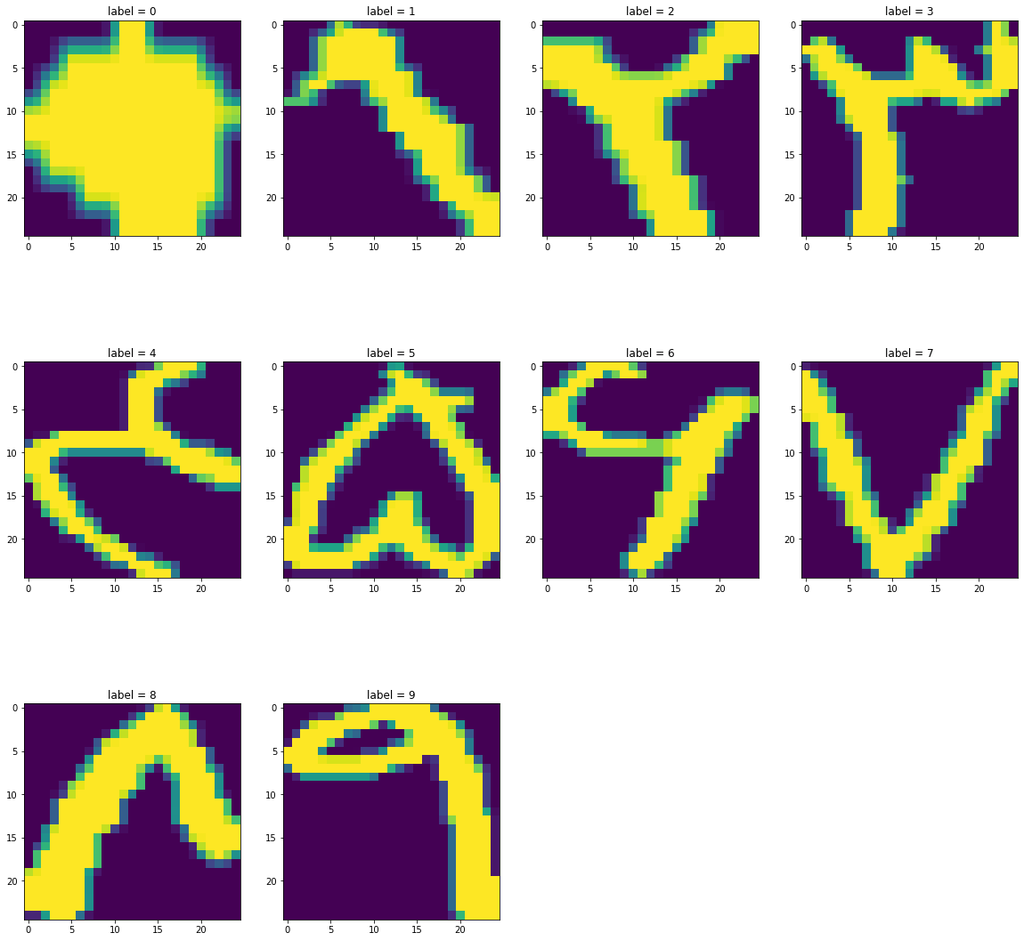

```python
labels_list = list(set(train_labels))
plt.figure(figsize=(20,20))
for i,label in enumerate(labels_list):
    index = train_labels.index(label)
    plt.subplot(3,4,i+1)
    plt.imshow(train_data[index])
    plt.title(f'label = {label}')
plt.show()
```

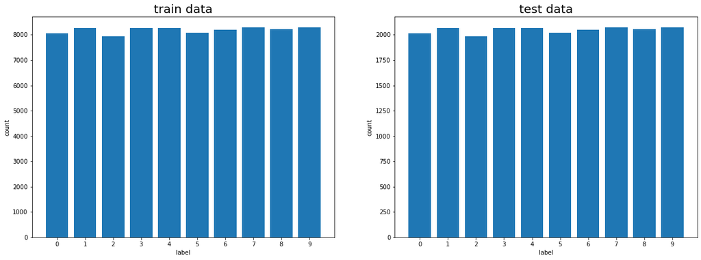

```python
train_labels_list = list(set(train_labels))
test_labels_list = list(set(test_labels))
train_freq = [train_labels.count(label) for label in train_labels_list]
test_freq = [test_labels.count(label) for label in test_labels_list]


plt.figure(figsize=(20,15))
plt.subplot(2,2,1)
plt.bar(train_labels_list, train_freq)
plt.xticks(train_labels_list)
plt.title('train data',fontsize=20)
plt.xlabel('label')
plt.ylabel('count')
plt.subplot(2,2,2)
plt.bar(test_labels_list, test_freq)
plt.xticks(test_labels_list)
plt.title('test data',fontsize=20)
plt.xlabel('label')
plt.ylabel('count')

plt.show()
```

## 4. Scaling

- If a feature in the Dataset is big in scale compared to others then this big scaled feature becomes dominating and as a result of that, predictions of the Neural Network will not be accurate.(weights in the neural network are initialized with a constant value according to the input range)
- Front Propagation of Neural Networks involves the dot Product of Weights with Input Features. So, if the Values are very high, calculation of output takes a lot of computation Time as well as Memory. Same is the case during Back Propagation. Consequently, model converges slowly, if the inputs are not Normalized.

```python
train_data = [(traindata/255) for traindata in train_data]
test_data = [(testdata/255) for testdata in test_data]
```

# Part 2

# Dataloader

```python
class Dataloader:
    '''
    This class prepares the dataset for the neural network.
    '''

    def __init__(self, data, labels, n_classes, batch_size=None, shuffle=False):
        '''
        This is the constructor. It gets dataset information and initializes the
        Dataloader class fields.
            Parameters:
                data: features your dataset in pandas.Dataframe format.
                labels: labels of your dataset in pandas.Dataframe format.
                n_classes: number of classes you have in your dataset.
                batch_size: the number of samples that will be propagated through the network.
                shuffle: boolean value indicating whether or not the dataset should be shuffled
        '''

        assert len(data)==len(labels)
        self.__n_classes = n_classes
        self.__batch_size = batch_size
        self.__shuffle = shuffle
        self.__data = data
        self.__onehot_labels = self.__onehot(labels, self.__n_classes)

    def __onehot(self, labels, n_classes):
        '''
        This private method gets labels and provides one_hot vectors of labels.
        For categorical variables where no such ordinal relationship exists,
        the integer encoding is not enough.
        In this case, a one-hot encoding can be applied to the integer representation.
        This is where the integer encoded variable is removed, and a new binary variable is
        added for each unique integer value.
        example:
            red,    green,    blue
            1,      0,        0
            0,      1,        0
            0,      0,        1
                Parameters:
                        label: lables of your dataset in pandas.Dataframe format.
                        n_classes: number of classes you have in your dataset.

                Returns:
                    onehot_vectors: onehot vectors of the labels

        '''

        # TODO: Implement
        onehot_vectors = np.eye(n_classes)[labels]
        return onehot_vectors

    def __shuffle_dataset(self):
        '''
        This private method shuffles your dataset.
        It uses data and onehot_labels to shuffle them
        symmetrical.
        '''
        random_vec = np.arange(len(self.__data))
        np.random.shuffle(random_vec)
        self.__data = self.__data[random_vec]
        self.__onehot_labels = self.__onehot_labels[random_vec]

        # TODO: Implement

    def __iter__(self):
        '''
        The __iter__() function returns an iterator for the
        given object (array, set, tuple, etc., or custom objects).
        This will return your dataset in the batch_size given. This should
        be used to provide data for the neural network.
        '''

        if self.__shuffle:
            self.__shuffle_dataset()

        if self.__batch_size==None:
            yield (np.matrix(self.__data), np.matrix(self.__onehot_labels))
            return

        for idx in range(0, len(self.__data), self.__batch_size):
            yield (np.matrix(self.__data[idx:idx+self.__batch_size]),
                   np.matrix(self.__onehot_labels[idx:idx+self.__batch_size]))
```

# Activation Functions

```python
class Identical:
    '''
    This is the Identical activation function. This activation function just
    return the value it gets.
    '''

    def __init__(self): pass
    '''
        This is the constructor. It does not have any fields
        as a result, there is no need to do anything in the constructor.
    '''
    def __val(self, matrix):
        '''
        This private method gets a matrix and uses the activity function on that.
        As this is an identical activity function, it just
        returns np.matrix of the input.

            Parameters:
                matrix: np.matrix of values
            Returns:
                identical_value: np.matrix of input with float datatypes
        '''

        identical_value = np.matrix(matrix, dtype=np.float64)
        return identical_value

    def derivative(self, matrix):
        '''
        This method returns the derivation of the input.
        As the derivation of x is one, this method returns
        a matrix of one with the shape of the input matrix.

            Parameters:
                matrix: np.matrix of values
            Returns:
                identical_derivative: np.matrix of ones with matrix shape
        '''

        temp = np.matrix(matrix, dtype=np.float64)
        identical_derivative = np.matrix(np.full(np.shape(temp), 1.))
        return identical_derivative

    def __call__(self, matrix):
        '''
        __call__ is a special function in Python that, when implemented inside a class,
        gives its instances (objects) the ability to behave like a function.
        Here we return the _value method output.

            Parameters:
                matrix: np.matrix of values
            Returns:
                __val(matrix): __val return value for the input matrix
        '''
        return self.__val(matrix)


class Relu:
    '''
    This is the Relu activation function.
    The rectified linear activation function or ReLU for short
    is a piecewise linear function that will output the input directly
    if it is positive, otherwise, it will output zero.
    '''

    def __init__(self): pass
    '''
            This is the constructor. It does not have any fields
            as a result, there is no need to do anything in the constructor.
    '''

    def __val(self, matrix):
      ###  '''
      #  This private method gets a matrix and uses the activity function on that.
        #It will set 0 in the matrix if the value is less than 0 else, it returns the value itself.

           # Parameters:
            #    matrix: np.matrix of values
           # Returns:
          ##      relu_value: np.matrix of relu activation function result
        ##'''
        ###'''''
        # TODO: Implement
      ###  '''''

        relu_value = numpy.maximum(matrix, 0.)

        return relu_value

    def derivative(self, matrix):
        '''

        Returns the derivation value of relu function on input matrix.

            Parameters:
                matrix: np.matrix of values
            Returns:
                relu_derivative: np.matrix of relu activation function derivation result

        '''
        # TODO: Implement
        relu_derivative = np.matrix(np.where(matrix > 0,1,0))

        return relu_derivative

    def __call__(self, matrix):
        '''''

        __call__ is a special function in Python that, when implemented inside a class,
        gives its instances (objects) the ability to behave like a function.
        Here we return the _relu method output.

            Parameters:
                matrix: np.matrix of values
            Returns:
                __relu(matrix): __relu return value for the input matrix

        '''
        return self.__val(matrix)

class LeakyRelu:
    ''''

    This is the Leaky Relu activation function.
    Leaky Rectified Linear Unit, or Leaky ReLU,
    is a type of activation function based on a ReLU,
    but it has a small slope for negative values instead
    of a flat slope.

    '''

    def __init__(self, negative_slope=0.01):
        ''''

        This is the constructor.
        It sets negative_slope field.
            Parameters:
                negative_slope: slope for negative input values

        '''
        self.negative_slope = 0.01

    def __val(self, matrix):
        ''''

        This private method gets a matrix and uses the activity function on that.
        It will set negative_slope*value in the matrix if the value is less than 0, else it
        returns the value itself.

            Parameters:
                matrix: np.matrix of values
            Returns:
                relu_value: np.matrix of relu activation function result

        '''


        # TODO: Implement

        leacky_relu_value = numpy.maximum(matrix, matrix*self.negative_slope)

        return leacky_relu_value

    def derivative(self, matrix):
        '''

        Returns the derivation value of leaky relu function on input matrix.

            Parameters:
                matrix: np.matrix of values
            Returns:
                leacky_relu_derivative: np.matrix of leaky relu activation function derivation result

        '''

        leacky_relu_derivative = np.matrix(np.where(matrix > 0,1,self.negative_slope))

        # TODO: Implement

        return leacky_relu_derivative

    def __call__(self, matrix):
        ''''

        __call__ is a special function in Python that, when implemented inside a class,
        gives its instances (objects) the ability to behave like a function.
        Here we return the _val method output.

            Parameters:
                matrix: np.matrix of values
            Returns:
                __val(matrix): __val return value for the input matrix

        '''
        return self.__val(matrix)


class Sigmoid:
    ''''

    A sigmoid function is a mathematical function having a
    characteristic "S"-shaped curve or sigmoid curve.
    It return S(x)=1/(1+e^-x)

    '''

    def __init__(self): pass

    def __val(self, matrix):
        ''''

        Returns 1/(1+e^-x) of values

            Parameters:
                matrix: np.matrix of values
            Returns:
               sigmoid_value: np.matrix of relu activation function result

        '''
        # TODO: Implement

        sigmoid_value = np.matrix(1.0/(1.0 + np.exp(-matrix)))

        return sigmoid_value

    def derivative(self, matrix):
        ''''

        Returns the derivation value of sigmoid function on input matrix.

            Parameters:
                matrix: np.matrix of values
            Returns:
                sigmoid_derivative: np.matrix of sigmoid activation function derivation result

        '''
        # TODO: Implement

        sigmoid_derivative = numpy.multiply(self.__val(matrix), (1. - self.__val(matrix)))

        return sigmoid_derivative

    def __call__(self, matrix):
        ''''

        __call__ is a special function in Python that, when implemented inside a class,
        gives its instances (objects) the ability to behave like a function.
        Here we return the _val method output.

            Parameters:
                matrix: np.matrix of values
            Returns:
                __val(matrix): __val return value for the input matrix

        '''
        return self.__val(matrix)


class Softmax:
    ''''

    The softmax function, also known as softargmax  or normalized
    exponential function is a generalization of the logistic
    function to multiple dimensions. It is used in multinomial logistic
    regression and is often used as the last activation function of a neural
    network to normalize the output of a network to a probability distribution
    over predicted output classes, based on Luce's choice axiom.
    Softmax return (e^x_i / (Σe^x_j for j = 1, ..., J))
    '''


    def __init__(self): pass
    '''
        This is the constructor. It does not have any fields
        as a result, there is no need to do anything in the constructor.
    '''

    def __val(self, matrix):
        '''
        This private method gets a matrix and uses the softmax on that.
        Softmax return (e^x_i / (Σe^x_j for j = 1, ..., J))

            Parameters:
                matrix: np.matrix of values
            Returns:
                relu_value: np.matrix of relu activation function result
        '''

        # TODO: Implement
       # x_off = matrix - np.max(matrix)
        #softmax_value = x_off - np.log((np.exp(x_off)).sum(axis=1))

       # softmax_value = np.exp(matrix - np.max(matrix)) / np.exp(matrix - np.max(matrix)).sum(axis=1)


        b = matrix.max()
        y = np.exp(matrix - b)
        softmax_value = y / y.sum(axis = 1)


        return softmax_value

    def __call__(self, matrix):
        '''
        __call__ is a special function in Python that, when implemented inside a class,
        gives its instances (objects) the ability to behave like a function.
        Here we return the _val method output.

            Parameters:
                matrix: np.matrix of values
            Returns:
                __val(matrix): __val return value for the input matrix
        '''
        return self.__val(matrix)

class Tanh:
    '''
      This is the constructor. It does not have any fields
      as a result, there is no need to do anything in the constructor.
    '''

    def __init__(self): pass

    def __val(self, matrix):
        '''
        This private method gets a matrix and uses the activity function on that.
        It performs Tanh on the values.

            Parameters:
                matrix: np.matrix of values
            Returns:
                tanh_value: np.matrix of Tanh activation function result
        '''

        # TODO: Implement

       # tanh_value = numpy.matrix((numpy.exp(matrix) - numpy.exp(-matrix)) / (numpy.exp(matrix) + numpy.exp(matrix)))
        tanh_value = np.tanh(matrix)
        return tanh_value


    def derivative(self, matrix):

        '''
        Returns the derivation value of Tanh function on input matrix.

            Parameters:
                matrix: np.matrix of values
            Returns:
                sigmoid_derivative: np.matrix of Tanh activation function derivation result
        '''
        # TODO: Implement
        tanh_derivative = 1 - numpy.power(self.__val(matrix), 2)

        return tanh_derivative


    def __call__(self, matrix):
        '''
        __call__ is a special function in Python that, when implemented inside a class,
        gives its instances (objects) the ability to behave like a function.
        Here we return the _val method output.

            Parameters:
                matrix: np.matrix of values
            Returns:
                __val(matrix): __val return value for the input matrix
        '''

        return self.__val(matrix)
```


# Loss Function

```python
class CrossEntropy: #(with softmax)
    '''
    Cross-entropy is a measure of the difference between two probability
    distributions for a given random variable or set of events. You might
    recall that information quantifies the number of bits required to encode
    and transmit an event.
    The above image can help you.
    '''

    def __init__(self): pass
    '''
        This is the constructor. It does not have any fields
        as a result, there is no need to do anything in the constructor.
    '''

    def __val(self, true_val, expected_val):
        '''
        L(y^, y) = - Σ (y^(k)log (y^)^(k)) for k in K
        Parameters:
            true_val: calculated values (generated by neural network)
            expected_val: real values in dataset
        Returns:
            cross_entropy_value: cross entropy of inputs
        '''
        assert np.shape(true_val)==np.shape(expected_val)
        # TODO: Implement

        cross_entropy_value = -numpy.sum(numpy.multiply(numpy.matrix(expected_val), numpy.log(Softmax()(true_val))), axis=1)

        return cross_entropy_value

    def derivative(self, true_val, expected_val):
        '''
        Returns derivation of cross entropy.
            Parameters:
                true_val: calculated values (generated by neural network)
                expected_val: real values in dataset
            Returns:
                cross_entropy_derivative: cross entropy derivation of inputs
        '''
        assert np.shape(true_val)==np.shape(expected_val)
        # TODO: Implement
        cross_entropy_derivative = Softmax()(true_val) - expected_val

        return cross_entropy_derivative

    def __call__(self, true_val, expected_val):
        '''
        __call__ is a special function in Python that, when implemented inside a class,
        gives its instances (objects) the ability to behave like a function.
        Here we return the _val method output.

            Parameters:
                true_val: calculated values (generated by neural network)
                expected_val: real values in dataset
            Returns:
                __val(matrix): __val return value for the input matrix
        '''
        return self.__val(true_val, expected_val)
```

# Layer

```python
class Layer:
    '''
    The layer class is used to define neural network layers.
    It stores all needed information for each layer, such as neurons count,
    weight matrix, bias, the output after applying the activation function, etc.
    '''

    DEFAULT_LOW, DEFAULT_HIGH, DEFAULT_MEAN, DEFAULT_VAR = 0, 0.05, 0., 1.
    #DEFAULT_LOW, DEFAULT_HIGH, DEFAULT_MEAN, DEFAULT_VAR = 2, 5, 0., 1.

    def __init__(self, input_size, output_size, activation=Identical(), initial_weight='uniform',
                 **initializing_parameters):
        '''
        Parameters:
            input_size: the size of the input of this layer.
            output_size: the size of the output after this layer.
            activation: the activation function. It can be initialized to either of the previously defined activation classes.
                               default is an Identical activation function.
            initial_weight: either normal or uniform. It defines the method for weight initialization.
        '''

        assert type(initial_weight)==str, 'Undefined activation function!'

        self.__weight_initializer_dict = {'uniform':self.__uniform_weight, 'normal':self.__normal_weight}

        assert initial_weight in self.__weight_initializer_dict, 'Undefined weight initialization function!'


        self.__n_neurons = output_size
        weight_initializer = self.__weight_initializer_dict[initial_weight]
        self.__weight = weight_initializer(input_size, self.__n_neurons, **initializing_parameters)
        self.__bias = weight_initializer(1, self.__n_neurons, **initializing_parameters)
        self.__activation = activation

        self.__last_input = None
        self.__last_activation_input = None
        self.__last_activation_output = None
        self.__last_activation_derivative = None

    def forward(self, layer_input):
        '''
        It calculates the output of this layer for the layer_input argument.
        This method also stores __last_input, __last_activation_input, and __last_activation_derivative
        for future use in backpropagation.
        Parameters:
            layer_input: 2d np.matrix representing the input matrix of this layer.
        Returns:
            Final output of this layer after applying the activation function.
        '''
        assert np.ndim(layer_input)==2
        assert np.size(self.__weight,0) == np.size(layer_input,1)
        # TODO: Implement

        self.__last_input = layer_input
        self.__last_activation_input = np.add(np.dot(self.__last_input, self.__weight), self.__bias)
        self.__last_activation_output = self.__activation(self.__last_activation_input)
        self.__last_activation_derivative = self.__activation.derivative(self.__last_activation_output)

        return self.__last_activation_output

    def update_weights(self, backprop_tensor, lr):
        '''
        It updates Layer weights according to the backpropagation matrix and learning rate.
        This method updates bias values as well.
        Parameters:
            backprop_tensor: 2d np.matrix passed from the next layer containing gradient values.
            lr: learning rate
        Returns:
            backprop_tensor to be used by the previous layer.
        '''
        assert np.ndim(backprop_tensor)==2
        assert np.size(backprop_tensor,0) == np.size(self.__last_activation_derivative,0)
        assert np.size(backprop_tensor,1) == self.__n_neurons
        # TODO: Implement

        backprop_tensor = np.multiply(backprop_tensor, self.__last_activation_derivative)
        self.__weight = self.__weight - (lr * np.dot(self.__last_input.transpose(), backprop_tensor))

        onesMatrix = np.matrix((np.ones(backprop_tensor.shape[0])))

        self.__bias = self.__bias - (lr * np.dot(onesMatrix ,backprop_tensor))


        backprop_tensor = np.dot(backprop_tensor, self.__weight.transpose())


        return backprop_tensor

    def __uniform_weight(self, dim1, dim2, **initializing_parameters):
        '''
        Initializes weights as a uniform distribution between low and high values.
        It uses default low and high values unless low or high are passed in initializing_parameters.
        Parameters:
            dim1: the size of the first dimension of weights.
            dim2: the size of the second dimension of weights.
            initializing_parameters: other initializing parameters; it can include custom low or high values.
        Returns:
            np.matrix with size (dim1, dim2) initialized using uniformly distributed values.
        '''
        low, high = self.DEFAULT_LOW, self.DEFAULT_HIGH
        if 'low' in initializing_parameters.keys(): low = initializing_parameters['low']
        if 'high' in initializing_parameters.keys(): high = initializing_parameters['high']
        # TODO: Implement

        weights = np.random.uniform(low, high=high, size=(dim1, dim2))

        return weights

    def __normal_weight(self, dim1, dim2, **initializing_parameters):
        '''
        Initializes weights as a normal distribution with mean and var values.
        It uses default mean and variance values unless mean or var are passed in initializing_parameters.
        Parameters:
            dim1: the size of the first dimension of weights.
            dim2: the size of the second dimension of weights.
            initializing_parameters: other initializing parameters; it can include custom mean or var values.
        Returns:
            np.matrix with size (dim1, dim2) initialized using normaly distributed values.
        '''
        mean, var = self.DEFAULT_MEAN, self.DEFAULT_VAR
        if 'mean' in initializing_parameters.keys(): mean = initializing_parameters['mean']
        if 'var' in initializing_parameters.keys(): var = initializing_parameters['var']
        # TODO: Implement

        weights = np.random.normal(loc=mean, scale=var, size=(dim1, dim2))

        return weights

    @property
    def n_neurons(self): return self.__n_neurons

    @property
    def weight(self): return self.__weight

    @property
    def bias(self): return self.__bias

    @property
    def activation(self): return self.__activation

    def printt(self):
        print("weith ",self.__weight[0])
```

# Feed Forward Neural Network

```python
class FeedForwardNN:
    '''
    This class is used in order to implement custom feed-forward neural networks.
    The FeedForwardNN class stores a list of layers that determines all network layers.
    It also consists of the learning rate and loss function.
    '''
    def __init__(self, input_shape):
        '''
        Parameters:
            input_shape: the size of the first input to our neural network.
        '''

        self.__input_shape = input_shape
        self.__output_shape = None

        self.__layers_list = []

        self.__lr = None
        self.__loss = None


    def add_layer(self, n_neurons, activation=Relu(), initial_weight='uniform', **initializing_parameters):
        '''
         This method adds a new custom layer to the layers_list.
         Parameters:
             n_neurons: number of neurons in this layer
             activation: the activation function of this layer, default is Relu
             initial_weight: either a uniform or normal, default is uniform
             initializing_parameters: other initializing parameters such as low, high, mean, var, etc
        '''

        assert type(n_neurons)==int, "Invalid number of neurons for the layer!"
        assert n_neurons>0, "Invalid number of neurons for the layer!"

        n_prev_neurons = self.__input_shape if len(self.__layers_list)==0 else self.__layers_list[-1].n_neurons
        new_layer = Layer(n_prev_neurons, n_neurons, activation, initial_weight, **initializing_parameters)
        self.__layers_list.append(new_layer)
        self.__output_shape = self.__layers_list[-1].n_neurons


    def set_training_param(self, loss=CrossEntropy(), lr=1e-3):
        '''
        This method is used to set training parameters.
        Parameters:
            loss: loss function, default is CrossEntropy
            lr: learning rate, default is 1e-3
        '''
        assert self.__layers_list, "Uncomplete model!"
        self.__loss = loss
        self.__lr = lr


    def forward(self, network_input):
        '''
        This method calculates the output of the complete neural network for a passed input.
        Parameters:
            network_input: input of the neural network
        Returns:
            network_output: output of the neural network after forwarding the network_input
        '''
        assert type(self.__output_shape) != None, "Model is not compiled!"
        # TODO: Implement

        network_output = network_input
        for i in range(len(self.__layers_list)):
            network_output = self.__layers_list[i].forward(network_output)

        return network_output


    def fit(self, epochs, trainloader, testloader=None, print_results=True):
        '''
        This method trains the neural network using specified parameters.
        It runs the __train private method epoch times and fills the log dictionary.
        Parameters:
            epochs: number of epochs to run
            trainloader: DataLoader for train data
            testloader: DataLoader for test data
            print_results: whether or not to print the results
        Returns:
            log: complete log of the training process as a dictionary consisting of
            train_accuracy, train_loss, test_accuracy, test_loss
        '''

        assert type(self.__output_shape) != None, "Model is not compiled!"
        assert type(self.__lr) != None and type(self.__loss) != None, "Training paramenters are not set!"

        log = {"train_accuracy":[], "train_loss":[], "test_accuracy":[], "test_loss":[]}

        for epoch in range(1, epochs+1):
          #  print("wietgs ", self.__layers_list[0].printt())
            if print_results:
                print('Epoch {}:'.format(epoch))

            average_accuracy, average_loss = self.__train(trainloader)
            log['train_accuracy'].append(average_accuracy)
            log['train_loss'].append(average_loss)
            if print_results:
                print('\tTrain: Average Accuracy: {}\tAverage Loss: {}'.format(average_accuracy, average_loss))

            if type(testloader) != type(None):
                average_accuracy, average_loss = self.__test(testloader)
                log['test_accuracy'].append(average_accuracy)
                log['test_loss'].append(average_loss)
                if print_results:
                    print('\tTest: Average Accuracy: {}\tAverage Loss: {}'.format(average_accuracy, average_loss))

        return log


    def __train(self, trainloader):
        '''
        Trains the neural network for one epoch.
        Parameters:
            trainloader: A DataLoader consisting of train data
        Returns:
            batch_accuracy, batch_loss: mean of all batch_accuracies, batch_losses
        '''
        bach_accuracies, batch_losses = [], []
        for x_train, y_train in trainloader:
            batch_accuracy, batch_loss = self.__train_on_batch(x_train, y_train)
            bach_accuracies.append(batch_accuracy)
            batch_losses.append(batch_loss)
        return np.mean(bach_accuracies), np.mean(batch_losses)


    def __test(self, testloader):
        '''
        Test the neural network using a testloader.
        Parameters:
            testloader: A DataLoader of test data
        Returns:
            batch_accuracy, batch_loss: mean of all batch_accuracies, batch_losses
        '''
        bach_accuracies, batch_losses = [], []
        for x_test, y_test in testloader:
            batch_accuracy, batch_loss = self.__test_on_batch(x_test, y_test)
            bach_accuracies.append(batch_accuracy)
            batch_losses.append(batch_loss)
        return np.mean(bach_accuracies), np.mean(batch_losses)


    def __train_on_batch(self, x_batch, y_batch):
        '''
        Trains the neural network for one batch of train data.
        Parameters:
            x_batch: one batch data
            y_batch: labels for one batch
        Returns:
            (batch_accuracy, batch_average_loss)
        '''
        # TODO: Implement

        output = self.forward(x_batch)

        self.__update_weights(output, y_batch)

        batch_accuracy = self.__compute_accuracy(output, y_batch)

        batch_average_loss = numpy.mean(self.__loss(output, y_batch))


        return (batch_accuracy, batch_average_loss)


    def __test_on_batch(self, x_batch, y_batch):
        '''
        Tests the neural network for one batch of test data.
        Parameters:
            x_batch: one batch data
            y_batch: labels for one batch
        Returns:
            (batch_accuracy, batch_average_loss)
        '''
        # TODO: Implement

        output = self.forward(x_batch)
        batch_accuracy = self.__compute_accuracy(output, y_batch)
        batch_average_loss = numpy.mean(self.__loss(output, y_batch))


        return (batch_accuracy, batch_average_loss)


    def __get_labels(self, outputs):
        '''
        Parameters:
            outputs: output of the neural network
        Returns:
            labels: labels generated from the outputs of the neural network
        '''
        # TODO: Implement
        labels = numpy.argmax(outputs, axis=1)

        return labels


    def __compute_accuracy(self, output, expected_output):
        '''
        Computes accuracy by comparing output and expected_output.
        Parameters:
            output: actual output of the neural network
            expected_output: expected output
        Returns:
            accuracy
        '''
        # TODO: Implement
        accuracy = ((self.__get_labels(output) == self.__get_labels(expected_output)).sum() / numpy.size(output,0))*100

        return accuracy


    def __update_weights(self, output, y_train):
        '''
        Updates weights of all layers according to neural network output and labels.
        Parameters:
            output: output of the neural network
            y_train: y labels for one batch of train data
        Returns:
            None
        '''
        # TODO: Implement
        for i in (range(len(self.__layers_list)-1,-1,-1)):
            if i == (len(self.__layers_list) - 1):
                backPropagationVal = self.__layers_list[i].update_weights(self.__loss.derivative(output, y_train), self.__lr)
            else:
                backPropagationVal = self.__layers_list[i].update_weights(backPropagationVal, self.__lr)

        return
```

# Training Sample Code

## Part1 Train the network

As you can see accuracy does not change much. which is probably caused by by dying relu problem. With high learnign rate, there is a significant chance that new weights end up in the highly negative value range since old weights are subtracted by a large number. These negative weights result in negative inputs for ReLU, thereby causing the dying ReLU problem to happen

```python
INPUT_SHAPE = 625
LEARNING_RATE = 1e-03
EPOCHS = 15
BATCH_SIZE = 32

train_labels = np.array(train_labels)

test_labels = np.array(test_labels)

train_data = np.asarray(train_data).astype(np.float64)
train_data=train_data.reshape(len(train_data), -1)

test_data = np.asarray(test_data).astype(np.float64)
test_data = test_data.reshape(len(test_data), -1)

TRAINLOADER = Dataloader(train_data, train_labels, 10,BATCH_SIZE,shuffle = True)
TESTLOADER = Dataloader(test_data, test_labels, 10,BATCH_SIZE,shuffle = True)

network = FeedForwardNN(INPUT_SHAPE)
network.add_layer(20, input_shape=INPUT_SHAPE, activation=Relu(), weight_initializer='uniform')
#network.add_layer(10, input_shape=INPUT_SHAPE, activation=Relu(), weight_initializer='uniform')
network.add_layer(10, activation=Relu(), weight_initializer='uniform')
network.set_training_param(loss=CrossEntropy(), lr=LEARNING_RATE)

log = network.fit(EPOCHS, TRAINLOADER, TESTLOADER,print_results=True)
```

```
Epoch 1:
	Train: Average Accuracy: 9.829962876123485	Average Loss: 2.317850157457071
	Test: Average Accuracy: 9.83589504076087	Average Loss: 2.3025850929940455
Epoch 2:
	Train: Average Accuracy: 9.838511137162953	Average Loss: 2.3025850929940455
	Test: Average Accuracy: 9.843537703804348	Average Loss: 2.3025850929940455
Epoch 3:
	Train: Average Accuracy: 9.838853067604534	Average Loss: 2.3025850929940455
	Test: Average Accuracy: 9.83971637228261	Average Loss: 2.3025850929940455
Epoch 4:
	Train: Average Accuracy: 9.838853067604534	Average Loss: 2.3025850929940455
	Test: Average Accuracy: 9.83589504076087	Average Loss: 2.3025850929940455
Epoch 5:
	Train: Average Accuracy: 9.838169206721375	Average Loss: 2.3025850929940455
	Test: Average Accuracy: 9.837805706521738	Average Loss: 2.3025850929940455
Epoch 6:
	Train: Average Accuracy: 9.838511137162953	Average Loss: 2.3025850929940455
	Test: Average Accuracy: 9.841627038043478	Average Loss: 2.3025850929940455
Epoch 7:
	Train: Average Accuracy: 9.837827276279796	Average Loss: 2.3025850929940455
	Test: Average Accuracy: 9.841627038043478	Average Loss: 2.3025850929940455
Epoch 8:
	Train: Average Accuracy: 9.839194998046112	Average Loss: 2.3025850929940455
	Test: Average Accuracy: 9.843537703804348	Average Loss: 2.3025850929940455
Epoch 9:
	Train: Average Accuracy: 9.838511137162953	Average Loss: 2.3025850929940455
	Test: Average Accuracy: 9.843537703804348	Average Loss: 2.3025850929940455
Epoch 10:
	Train: Average Accuracy: 9.838169206721375	Average Loss: 2.3025850929940455
	Test: Average Accuracy: 9.833984375	Average Loss: 2.3025850929940455
Epoch 11:
	Train: Average Accuracy: 9.838853067604534	Average Loss: 2.3025850929940455
	Test: Average Accuracy: 9.837805706521738	Average Loss: 2.3025850929940455
Epoch 12:
	Train: Average Accuracy: 9.838853067604534	Average Loss: 2.3025850929940455
	Test: Average Accuracy: 9.837805706521738	Average Loss: 2.3025850929940455
Epoch 13:
	Train: Average Accuracy: 9.840220789370848	Average Loss: 2.3025850929940455
	Test: Average Accuracy: 9.843537703804348	Average Loss: 2.3025850929940455
Epoch 14:
	Train: Average Accuracy: 9.838511137162953	Average Loss: 2.3025850929940455
	Test: Average Accuracy: 9.843537703804348	Average Loss: 2.3025850929940455
Epoch 15:
	Train: Average Accuracy: 9.838511137162953	Average Loss: 2.3025850929940455
	Test: Average Accuracy: 9.833984375	Average Loss: 2.3025850929940455
```

## Part2: Weight Initialization

#### Zero Initialization

In each iteration of backpropagation, weights are updated by multiplying the existing weight by a delta determined by backpropagation. If the initial weight value is 0, they will not update in the backpropagation phase. Moreover, If all the weights are initialized to zeros, the derivatives will remain same for every w in W[l]. This makes hidden layers symmetric and neurons will learn same features in each iterations.Thus, with zero weights or any other constant weights, the network works no better than a linear model.

#### Random Initialization:

Random initialization is generally used to break the symmetry and this process gives much better accuracy than zero initialization. It prevents neuron from learning the same features of its inputs. But if the random weights are too low or too high we might face Vanishing gradients or Exploding gradients problem.

- ##### Vanishing gradients : For any activation function, derivation of weight will get smaller and smaller as we go backward with every layer during backpropagation. So, the earlier layers’ weights are adjusted slowly. Due to this, the weight update is minor which results in slower convergence.This makes the optimization of our loss function slow. In the case of the sigmoid and tanh and activation functions, if your weights are very large, then the gradient will be vanishingly small, effectively preventing the weights from changing their value. But in RELU activation function vanishing gradients are not a problem as the gradient is 0 for negative (and zero) values of inputs and 1 for positive values of inputs.
- ##### Exploding gradients : This is the exact opposite case of the vanishing gradients. Consider we have weights that are non-negative, large, and having small activations A. When these weights are multiplied along with the different layers, they cause a very large change in the value of the overall gradient (cost). This problem might result in the oscillation of the optimizer around the minima or even overshooting the optimum again and again and the model will never learn. Also, due to the large values of the gradients, it may cause numbers to overflow which results in incorrect computations or introductions of NaN’s.

## Part 3: The effect of learning rate

The learning rate indicates the step size that gradient descent takes towards local optima:

- With a large learning rate, the algorithm learns fast, but it may also cause the algorithm to oscillate around or even jump over the minima. Even worse, a high learning rate equals large weight updates, which might cause the weights to overflow.
- With a small learning rate, updates to the weights are small, which will guide the optimizer gradually towards the minima. However, the optimizer may take too long to converge or get stuck in a plateau or undesirable local minima.

#### Learning Rate grater than 1e-2

With learning rate grater higer than 0.01, weights becomes significantly high and in back propagation, beacause of overflow,softmax gets zero and loss becomes nan.Therefor the model accuray never changes and we get same results in each epoch.

```python
EPOCHS = 15
LEARNING_RATE = 0.0101
TRAINLOADER = Dataloader(train_data, train_labels, 10,BATCH_SIZE)
TESTLOADER = Dataloader(test_data, test_labels, 10,BATCH_SIZE)
network = FeedForwardNN(INPUT_SHAPE)
network.add_layer(20, input_shape=INPUT_SHAPE, activation=Relu(), weight_initializer='uniform')
network.add_layer(10, activation=Relu(), weight_initializer='uniform')
network.set_training_param(loss=CrossEntropy(), lr=LEARNING_RATE)
log = network.fit(EPOCHS, TRAINLOADER, TESTLOADER,print_results=True)
```

```
Epoch 1:
```

```
	Train: Average Accuracy: 9.838169206721375	Average Loss: nan
	Test: Average Accuracy: 9.83589504076087	Average Loss: nan
Epoch 2:
	Train: Average Accuracy: 9.838169206721375	Average Loss: nan
	Test: Average Accuracy: 9.83589504076087	Average Loss: nan
Epoch 3:
	Train: Average Accuracy: 9.838169206721375	Average Loss: nan
	Test: Average Accuracy: 9.83589504076087	Average Loss: nan
Epoch 4:
	Train: Average Accuracy: 9.838169206721375	Average Loss: nan
	Test: Average Accuracy: 9.83589504076087	Average Loss: nan
Epoch 5:
	Train: Average Accuracy: 9.838169206721375	Average Loss: nan
	Test: Average Accuracy: 9.83589504076087	Average Loss: nan
Epoch 6:
	Train: Average Accuracy: 9.838169206721375	Average Loss: nan
	Test: Average Accuracy: 9.83589504076087	Average Loss: nan
Epoch 7:
	Train: Average Accuracy: 9.838169206721375	Average Loss: nan
	Test: Average Accuracy: 9.83589504076087	Average Loss: nan
Epoch 8:
	Train: Average Accuracy: 9.838169206721375	Average Loss: nan
	Test: Average Accuracy: 9.83589504076087	Average Loss: nan
Epoch 9:
	Train: Average Accuracy: 9.838169206721375	Average Loss: nan
	Test: Average Accuracy: 9.83589504076087	Average Loss: nan
Epoch 10:
	Train: Average Accuracy: 9.838169206721375	Average Loss: nan
	Test: Average Accuracy: 9.83589504076087	Average Loss: nan
Epoch 11:
	Train: Average Accuracy: 9.838169206721375	Average Loss: nan
	Test: Average Accuracy: 9.83589504076087	Average Loss: nan
Epoch 12:
	Train: Average Accuracy: 9.838169206721375	Average Loss: nan
	Test: Average Accuracy: 9.83589504076087	Average Loss: nan
Epoch 13:
	Train: Average Accuracy: 9.838169206721375	Average Loss: nan
	Test: Average Accuracy: 9.83589504076087	Average Loss: nan
Epoch 14:
	Train: Average Accuracy: 9.838169206721375	Average Loss: nan
	Test: Average Accuracy: 9.83589504076087	Average Loss: nan
Epoch 15:
	Train: Average Accuracy: 9.838169206721375	Average Loss: nan
	Test: Average Accuracy: 9.83589504076087	Average Loss: nan
```

#### Learning Rate smaller than 1e-4

Since learning rate is too low, training progress very slowly because of making very tiny updates to the weights in the network. Thus we need to train network for more epochs to get a good result.

```python
EPOCHS = 15
LEARNING_RATE = 1e-05
TRAINLOADER = Dataloader(train_data, train_labels, 10,BATCH_SIZE)
TESTLOADER = Dataloader(test_data, test_labels, 10,BATCH_SIZE)
network = FeedForwardNN(INPUT_SHAPE)
network.add_layer(20, input_shape=INPUT_SHAPE, activation=Relu(), weight_initializer='uniform')
network.add_layer(10, activation=Relu(), weight_initializer='uniform')
network.set_training_param(loss=CrossEntropy(), lr=LEARNING_RATE)
log = network.fit(EPOCHS, TRAINLOADER, TESTLOADER,print_results=True)
```

```
Epoch 1:
	Train: Average Accuracy: 10.101944118796405	Average Loss: 2.2550293551697944
	Test: Average Accuracy: 9.83589504076087	Average Loss: 2.233490146012063
Epoch 2:
	Train: Average Accuracy: 12.349257522469715	Average Loss: 2.1836834760300543
	Test: Average Accuracy: 10.72944972826087	Average Loss: 2.1128485078477426
Epoch 3:
	Train: Average Accuracy: 32.57888823759281	Average Loss: 1.9738678183908542
	Test: Average Accuracy: 47.53969938858695	Average Loss: 1.8059423554158633
Epoch 4:
	Train: Average Accuracy: 57.58147713950762	Average Loss: 1.6166274532736198
	Test: Average Accuracy: 62.28664232336956	Average Loss: 1.4362543064615918
Epoch 5:
	Train: Average Accuracy: 69.03404650254005	Average Loss: 1.2834563499630576
	Test: Average Accuracy: 71.1389690896739	Average Loss: 1.1432158350831496
Epoch 6:
	Train: Average Accuracy: 75.32190308714341	Average Loss: 1.029175726255543
	Test: Average Accuracy: 76.6467815896739	Average Loss: 0.9246726746624404
Epoch 7:
	Train: Average Accuracy: 79.05539273153576	Average Loss: 0.8449084646410628
	Test: Average Accuracy: 80.01974354619566	Average Loss: 0.7713098359928476
Epoch 8:
	Train: Average Accuracy: 81.35731731144979	Average Loss: 0.717319039838066
	Test: Average Accuracy: 82.05587635869566	Average Loss: 0.6653536993191779
Epoch 9:
	Train: Average Accuracy: 83.15489449003518	Average Loss: 0.6276913404755562
	Test: Average Accuracy: 83.68185292119566	Average Loss: 0.5893166424226587
Epoch 10:
	Train: Average Accuracy: 84.45423016803439	Average Loss: 0.5616962971900994
	Test: Average Accuracy: 84.93185292119566	Average Loss: 0.5320572698085891
Epoch 11:
	Train: Average Accuracy: 85.56306174286831	Average Loss: 0.5108390430068689
	Test: Average Accuracy: 85.97677479619566	Average Loss: 0.48719733523158837
Epoch 12:
	Train: Average Accuracy: 86.48505275498242	Average Loss: 0.4702423407831447
	Test: Average Accuracy: 86.79517663043478	Average Loss: 0.4509930282203884
Epoch 13:
	Train: Average Accuracy: 87.29904259476358	Average Loss: 0.4369911028828772
	Test: Average Accuracy: 87.54712975543478	Average Loss: 0.42112237819267107
Epoch 14:
	Train: Average Accuracy: 88.02320242282141	Average Loss: 0.4092459729501964
	Test: Average Accuracy: 88.21798573369566	Average Loss: 0.3960638074237068
Epoch 15:
	Train: Average Accuracy: 88.68630324345447	Average Loss: 0.3857770914628384
	Test: Average Accuracy: 88.91134510869566	Average Loss: 0.37478202637833985
```

#### Finding best learning rate:

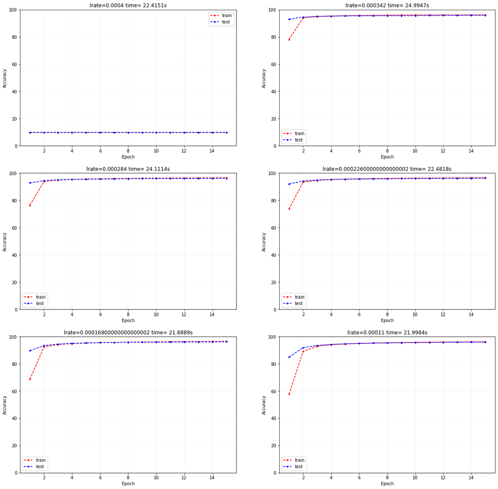

```
max accuracy is 96.201171875 and is achived by learning rate = 0.00022600000000000002
```

```python
def set_network(lrate,BATCH_SIZE,epochs ):
    TRAINLOADER = Dataloader(train_data, train_labels, 10,BATCH_SIZE)
    TESTLOADER = Dataloader(test_data, test_labels, 10,BATCH_SIZE)
    network = FeedForwardNN(INPUT_SHAPE)
    network.add_layer(20, input_shape=INPUT_SHAPE, activation=Relu(), weight_initializer='uniform')
    network.add_layer(10, activation=Relu(), weight_initializer='uniform')
    network.set_training_param(loss=CrossEntropy(), lr=lrate)
    log = network.fit(epochs, TRAINLOADER, TESTLOADER,print_results=False)
    return log


learning_rates = np.linspace(0.0004, 0.00011, num=6)
fig, ax = plt.subplots(3,2,figsize=(20,20))
maxAcc = 0
bestLR = 0
for plot_no , rate in enumerate(learning_rates):
    epochs = 15
    plt.grid(True, linewidth=0.1, color='gray', linestyle='-')
    plt.subplot(plot_no+1+320)
    s1 = time.time()
    log = set_network(rate,BATCH_SIZE,15)
    e1=time.time()
    if max(log['test_accuracy']) > maxAcc:
        maxAcc = max(log['test_accuracy'])
        bestLR =  rate
    plt.plot(list(range(1,epochs+1)),log['train_accuracy'], linestyle='--', marker='.',label='train',color='red')
    plt.plot(list(range(1,epochs+1)),log['test_accuracy'],linestyle='--', marker='.', label='test',color='blue')
    plt.title(f'lrate={str(rate)} time= {round(e1-s1,4)}s')
    plt.ylabel('Accuracy')
    plt.xlabel('Epoch')
    plt.ylim([0,100])
    plt.legend()

plt.show()
print(f'max accuracy is {maxAcc} and is achived by learning rate = {bestLR}')
```

## Part 4: Impact of Activation Function

An activation function in a neural network defines how the weighted sum of the input is transformed into an output from a node in a layer of the network. Without activation function, weight and bias would only have a linear transformation, or neural network is just a linear regression model, and so no matter how many layers the data goes through, the output is always the result of a linear function.

### sigmoid activation function

Sigmoid function takes any real value as input and outputs values in the range 0 to 1. The larger the input (more positive), the closer the output value will be to 1.0, whereas the smaller the input (more negative), the closer the output will be to 0.0.

f(x)=1/(1+e^(-x))

- when the neuron's activation saturates at either tail of 0 or 1, the gradient at these regions is almost zero. During backpropagation, we use the chain rule of differential to calculate the differential of each weight w. When the backpropagation passes through the sigmoid function, the differential on this chain is very small. Moreover, it may pass through many sigmoid functions, which will eventually cause the weight(w) to have little effect on the loss function, which is not conducive to the optimization of the weight. This problem is called gradient saturation or gradient dispersion.
- Sigmoid outputs are not zero-centered. This is undesirable since neurons in later layers of processing in a Neural Network would be receiving data that is not zero-centered. This has implications on the dynamics during gradient descent, because if the data coming into a neuron is always positive , then the gradient on the weights w will during backpropagation become either all be positive, or all negative. This could introduce undesirable zig-zagging dynamics in the gradient updates for the weights.

```python
LEARNING_RATE = 0.0001
def train_with_sigmoid(print_res=True):
    TRAINLOADER = Dataloader(train_data, train_labels, 10,BATCH_SIZE)
    TESTLOADER = Dataloader(test_data, test_labels, 10,BATCH_SIZE)
    network = FeedForwardNN(INPUT_SHAPE)
    network.add_layer(20, input_shape=INPUT_SHAPE, activation=Sigmoid(), weight_initializer='uniform')
    network.add_layer(10, activation=Sigmoid(), weight_initializer='uniform')
    network.set_training_param(loss=CrossEntropy(), lr=LEARNING_RATE)
    log = network.fit(EPOCHS, TRAINLOADER, TESTLOADER,print_results=print_res)
    return log

log = train_with_sigmoid(True)
```

```
Epoch 1:
	Train: Average Accuracy: 9.723378272762798	Average Loss: 2.3026588811055713
	Test: Average Accuracy: 9.83589504076087	Average Loss: 2.3025409254988016
Epoch 2:
	Train: Average Accuracy: 9.947196170379055	Average Loss: 2.3025532384745744
	Test: Average Accuracy: 10.12886379076087	Average Loss: 2.3024991655479434
Epoch 3:
	Train: Average Accuracy: 9.93742672919109	Average Loss: 2.302531357915404
	Test: Average Accuracy: 10.12886379076087	Average Loss: 2.3024865690307084
Epoch 4:
	Train: Average Accuracy: 9.947196170379055	Average Loss: 2.302521624111777
	Test: Average Accuracy: 10.12886379076087	Average Loss: 2.3024776324184755
Epoch 5:
	Train: Average Accuracy: 9.963071512309496	Average Loss: 2.302512639403052
	Test: Average Accuracy: 10.12886379076087	Average Loss: 2.3024681921092696
Epoch 6:
	Train: Average Accuracy: 10.003370457209847	Average Loss: 2.3025025369121983
	Test: Average Accuracy: 10.12886379076087	Average Loss: 2.3024573982877943
Epoch 7:
	Train: Average Accuracy: 10.007033997655334	Average Loss: 2.3024908108046853
	Test: Average Accuracy: 10.12886379076087	Average Loss: 2.302444818732722
Epoch 8:
	Train: Average Accuracy: 10.042448221961704	Average Loss: 2.3024770435297173
	Test: Average Accuracy: 10.12886379076087	Average Loss: 2.3024299808097437
Epoch 9:
	Train: Average Accuracy: 10.086410707307541	Average Loss: 2.302460710812547
	Test: Average Accuracy: 10.12886379076087	Average Loss: 2.3024122846875485
Epoch 10:
	Train: Average Accuracy: 10.174335677999219	Average Loss: 2.3024411320299
	Test: Average Accuracy: 10.12886379076087	Average Loss: 2.3023909560938476
Epoch 11:
	Train: Average Accuracy: 10.217076983196561	Average Loss: 2.302417420408085
	Test: Average Accuracy: 10.12886379076087	Average Loss: 2.3023649834127653
Epoch 12:
	Train: Average Accuracy: 10.230509964830011	Average Loss: 2.302388406674552
	Test: Average Accuracy: 10.12886379076087	Average Loss: 2.302333022394651
Epoch 13:
	Train: Average Accuracy: 10.278135990621337	Average Loss: 2.302352521129446
	Test: Average Accuracy: 10.12886379076087	Average Loss: 2.3022932500176463
Epoch 14:
	Train: Average Accuracy: 10.344079718640094	Average Loss: 2.3023076106236955
	Test: Average Accuracy: 10.13374660326087	Average Loss: 2.30224313616785
Epoch 15:
	Train: Average Accuracy: 10.402696365767879	Average Loss: 2.3022506484741756
	Test: Average Accuracy: 10.14351222826087	Average Loss: 2.3021790770711346
```

### Tanh Activation function

Tanh Activation function is superior then the Sigmoid Activation function because the range of this activation function is higher than the sigmoid activation function. Here negative values are also considered whereas in the sigmoid minimum range is 0 in Tanh, the minimum range is -1, thus Tanh performs better than Sigmoid. This is why the Tanh activation function is also known as the zero centered activation function.

Tanh has the same issue of Vanishing Gradient Problem like a sigmoid function.

f(x)=(e^x-e^(-x))/(e^x+e^(-x))

```python
def train_with_Tanh(print_res=True):
    TRAINLOADER = Dataloader(train_data, train_labels, 10,BATCH_SIZE)
    TESTLOADER = Dataloader(test_data, test_labels, 10,BATCH_SIZE)
    network = FeedForwardNN(INPUT_SHAPE)
    network.add_layer(20, input_shape=INPUT_SHAPE, activation=Tanh(), weight_initializer='uniform')
    network.add_layer(10, activation=Tanh(), weight_initializer='uniform')
    network.set_training_param(loss=CrossEntropy(), lr = LEARNING_RATE)
    log = network.fit(EPOCHS, TRAINLOADER, TESTLOADER,print_results=print_res)
    return log

log = train_with_Tanh(True)
```

```
Epoch 1:
	Train: Average Accuracy: 9.976162563501367	Average Loss: 2.303189196873995
	Test: Average Accuracy: 9.84077785326087	Average Loss: 2.303319243283945
Epoch 2:
	Train: Average Accuracy: 10.135599843688942	Average Loss: 2.30279297357788
	Test: Average Accuracy: 12.27241847826087	Average Loss: 2.301360314898333
Epoch 3:
	Train: Average Accuracy: 31.86083431027745	Average Loss: 2.039106917484891
	Test: Average Accuracy: 56.35996942934783	Average Loss: 1.661168546895616
Epoch 4:
	Train: Average Accuracy: 63.81335482610395	Average Loss: 1.5037980221957934
	Test: Average Accuracy: 66.6499660326087	Average Loss: 1.4035264469025415
Epoch 5:
	Train: Average Accuracy: 69.60086948026573	Average Loss: 1.3426259083138825
	Test: Average Accuracy: 70.52585767663044	Average Loss: 1.296609724187326
Epoch 6:
	Train: Average Accuracy: 73.43205353653771	Average Loss: 1.253605522992593
	Test: Average Accuracy: 74.07162873641305	Average Loss: 1.2284432479666019
Epoch 7:
	Train: Average Accuracy: 74.34305392731535	Average Loss: 1.2186336503712543
	Test: Average Accuracy: 75.2454144021739	Average Loss: 1.223938810407735
Epoch 8:
	Train: Average Accuracy: 74.69753810082064	Average Loss: 1.2195909987474884
	Test: Average Accuracy: 73.8293987771739	Average Loss: 1.225892068270611
Epoch 9:
	Train: Average Accuracy: 74.3577080890973	Average Loss: 1.2232246036957724
	Test: Average Accuracy: 74.57944123641305	Average Loss: 1.2310930943207847
Epoch 10:
	Train: Average Accuracy: 75.04523251270027	Average Loss: 1.243934876165869
	Test: Average Accuracy: 75.0940472146739	Average Loss: 1.2709480469854892
Epoch 11:
	Train: Average Accuracy: 74.78023642047675	Average Loss: 1.2911555340543195
	Test: Average Accuracy: 74.7473675271739	Average Loss: 1.31030479650834
Epoch 12:
	Train: Average Accuracy: 73.77188354826104	Average Loss: 1.3307766582132354
	Test: Average Accuracy: 73.22690217391305	Average Loss: 1.3372823809709102
Epoch 13:
	Train: Average Accuracy: 70.81838608831575	Average Loss: 1.349910211434367
	Test: Average Accuracy: 68.81092900815217	Average Loss: 1.3660638802544998
Epoch 14:
	Train: Average Accuracy: 67.90831379445096	Average Loss: 1.3856930685224824
	Test: Average Accuracy: 67.11171025815217	Average Loss: 1.4044485580079151
Epoch 15:
	Train: Average Accuracy: 66.41202618210238	Average Loss: 1.418912556183382
	Test: Average Accuracy: 65.66257642663044	Average Loss: 1.4301684391125666
```

#### Problem of Tanh and Sigmoid activation functions:

As mentioned earlier, both the Sigmoid and Tanh functions can make the model more susceptible to problems during training, via vanishing gradients problem.

### LeakyRelu activation function:

LeakyRelu is a variant of ReLU. Instead of being 0 when z<0, a leaky ReLU allows a small, non-zero, constant gradient α

In LeakyRelu like Relu, maximum Threshold values are Infinity, so there is no issue of Vanishing Gradient problem so the output prediction accuracy is maximum. Also Relu and LeakyRelu provides faster computation since they do not compute exponentials and divisions.

```python
def train_with_LeakyRelu(print_res = True):
    TRAINLOADER = Dataloader(train_data, train_labels, 10,BATCH_SIZE)
    TESTLOADER = Dataloader(test_data, test_labels, 10,BATCH_SIZE)
    network = FeedForwardNN(INPUT_SHAPE)
    network.add_layer(20, input_shape=INPUT_SHAPE, activation=LeakyRelu(), weight_initializer='uniform')
    network.add_layer(10, activation=LeakyRelu(), weight_initializer='uniform')
    network.set_training_param(loss=CrossEntropy(), lr=LEARNING_RATE)
    log = network.fit(EPOCHS, TRAINLOADER, TESTLOADER,print_results=print_res)
    return log

log = train_with_LeakyRelu(True)
```

```
Epoch 1:
	Train: Average Accuracy: 54.640338022665105	Average Loss: 1.3751245674166923
	Test: Average Accuracy: 83.67697010869566	Average Loss: 0.5552283282462815
Epoch 2:
	Train: Average Accuracy: 88.35414224306369	Average Loss: 0.3996669884475354
	Test: Average Accuracy: 91.43958050271739	Average Loss: 0.3021219878498075
Epoch 3:
	Train: Average Accuracy: 92.63349941383353	Average Loss: 0.26283891059972986
	Test: Average Accuracy: 93.14070991847827	Average Loss: 0.23688524637240657
Epoch 4:
	Train: Average Accuracy: 93.74721570926143	Average Loss: 0.21952941560347985
	Test: Average Accuracy: 94.01961616847827	Average Loss: 0.20954462439850588
Epoch 5:
	Train: Average Accuracy: 94.30407385697538	Average Loss: 0.19798313594518438
	Test: Average Accuracy: 94.49324898097827	Average Loss: 0.19354493737618444
Epoch 6:
	Train: Average Accuracy: 94.72415982805784	Average Loss: 0.18437216583706453
	Test: Average Accuracy: 94.84969429347827	Average Loss: 0.18266029299825157
Epoch 7:
	Train: Average Accuracy: 95.0050312622118	Average Loss: 0.17470889065880707
	Test: Average Accuracy: 95.09871773097827	Average Loss: 0.17461770765549564
Epoch 8:
	Train: Average Accuracy: 95.2517096522079	Average Loss: 0.1673477226253121
	Test: Average Accuracy: 95.27449898097827	Average Loss: 0.1683251705838227
Epoch 9:
	Train: Average Accuracy: 95.44221375537319	Average Loss: 0.1614327248477382
	Test: Average Accuracy: 95.41610054347827	Average Loss: 0.1632439745974727
Epoch 10:
	Train: Average Accuracy: 95.58142829230168	Average Loss: 0.1565062096483854
	Test: Average Accuracy: 95.60844089673913	Average Loss: 0.15899377297226186
Epoch 11:
	Train: Average Accuracy: 95.70354630715123	Average Loss: 0.15230330484784652
	Test: Average Accuracy: 95.70121433423913	Average Loss: 0.15540764676306534
Epoch 12:
	Train: Average Accuracy: 95.8183372411098	Average Loss: 0.1486388580720958
	Test: Average Accuracy: 95.72074558423913	Average Loss: 0.1522691308736196
Epoch 13:
	Train: Average Accuracy: 95.9306858147714	Average Loss: 0.14538256729535137
	Test: Average Accuracy: 95.82328464673913	Average Loss: 0.14950491039486108
Epoch 14:
	Train: Average Accuracy: 96.04914028917545	Average Loss: 0.14246052268506168
	Test: Average Accuracy: 95.88676120923913	Average Loss: 0.14704356896802678
Epoch 15:
	Train: Average Accuracy: 96.1175263774912	Average Loss: 0.13978583858508112
	Test: Average Accuracy: 95.95023777173913	Average Loss: 0.14492323334804363
```

#### Advantag of LeakyRelu over Relu:

The dying ReLU is problem when the neurons become inactive and output only 0 values basically negative values. This most probably occurs by learning a significant negative bias term for its weights.

The moment the ReLU ends up in this state, it cannot recover, since the function gradient at 0 is also 0. When the sigmoid and tanh neurons' values saturate, they can have comparable/similar problems, but there is always a modest gradient that allows them to recover in the long run. The dying ReLU problem usually happens at one of these cases:

1. Large Negative Bias: A large negative bias can make the ReLU activation inputs to become negative. As mentioned earlier, a negative input will output 0, which will lead to the dying ReLU problem.
2. High Learning Rate: Because old weights will be subtracted by a huge number if our learning rate is set too high, there is a good probability that our new weights will end up in the severely negative value range. Negative weights result in negative ReLU inputs, resulting in the dying ReLU problem.

```python
def train_with_Relu(print_res=True):
    TRAINLOADER = Dataloader(train_data, train_labels, 10,BATCH_SIZE)
    TESTLOADER = Dataloader(test_data, test_labels, 10,BATCH_SIZE)
    network = FeedForwardNN(INPUT_SHAPE)
    network.add_layer(20, input_shape=INPUT_SHAPE, activation=Relu(), weight_initializer='uniform')
    network.add_layer(10, activation=Relu(), weight_initializer='uniform')
    network.set_training_param(loss=CrossEntropy(), lr=LEARNING_RATE)
    log = network.fit(EPOCHS, TRAINLOADER, TESTLOADER,print_results=print_res)
    return log
log = train_with_Relu(True)
```

```
Epoch 1:
	Train: Average Accuracy: 56.590562719812425	Average Loss: 1.3326219618616515
	Test: Average Accuracy: 84.71212635869566	Average Loss: 0.5295060458332979
Epoch 2:
	Train: Average Accuracy: 88.5690699491989	Average Loss: 0.389672025568912
	Test: Average Accuracy: 91.48352581521739	Average Loss: 0.3004046066661267
Epoch 3:
	Train: Average Accuracy: 92.67257717858539	Average Loss: 0.2620803447449549
	Test: Average Accuracy: 93.18953804347827	Average Loss: 0.23726656451319378
Epoch 4:
	Train: Average Accuracy: 93.77774521297381	Average Loss: 0.21980937897019517
	Test: Average Accuracy: 93.93660835597827	Average Loss: 0.210600809465011
Epoch 5:
	Train: Average Accuracy: 94.31384329816335	Average Loss: 0.19859735115923643
	Test: Average Accuracy: 94.42000679347827	Average Loss: 0.19488958104370716
Epoch 6:
	Train: Average Accuracy: 94.71561156701837	Average Loss: 0.18505890287039203
	Test: Average Accuracy: 94.74715523097827	Average Loss: 0.18409157141255922
Epoch 7:
	Train: Average Accuracy: 94.99526182102383	Average Loss: 0.17539162934550043
	Test: Average Accuracy: 95.05477241847827	Average Loss: 0.17607014305977242
Epoch 8:
	Train: Average Accuracy: 95.2480461117624	Average Loss: 0.16801208616972302
	Test: Average Accuracy: 95.27449898097827	Average Loss: 0.16978699380629875
Epoch 9:
	Train: Average Accuracy: 95.45442555685815	Average Loss: 0.16210959015964999
	Test: Average Accuracy: 95.36918308423913	Average Loss: 0.1646967210624942
Epoch 10:
	Train: Average Accuracy: 95.58509183274717	Average Loss: 0.15723737226619955
	Test: Average Accuracy: 95.45219089673913	Average Loss: 0.16045396017397148
Epoch 11:
	Train: Average Accuracy: 95.73407581086362	Average Loss: 0.15309714772446978
	Test: Average Accuracy: 95.55961277173913	Average Loss: 0.15688567707256265
Epoch 12:
	Train: Average Accuracy: 95.83543376318875	Average Loss: 0.1495018800936367
	Test: Average Accuracy: 95.64262058423913	Average Loss: 0.153812858444974
Epoch 13:
	Train: Average Accuracy: 95.92091637358344	Average Loss: 0.14633969656543655
	Test: Average Accuracy: 95.68168308423913	Average Loss: 0.1510878443700901
Epoch 14:
	Train: Average Accuracy: 96.0125048847206	Average Loss: 0.14351203890302172
	Test: Average Accuracy: 95.77445652173913	Average Loss: 0.1486538565160779
Epoch 15:
	Train: Average Accuracy: 96.08211215318484	Average Loss: 0.140943068216309
	Test: Average Accuracy: 95.81840183423913	Average Loss: 0.14642538951472656
```

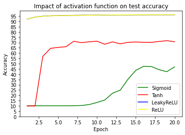

```python
EPOCHS = 20
log = train_with_sigmoid(False)
plt.plot(list(range(1,EPOCHS+1)),log['test_accuracy'], label='Sigmoid',color='green')
log = train_with_Tanh(False)
plt.plot(list(range(1,EPOCHS+1)),log['test_accuracy'], label='Tanh',color='red')
log = train_with_LeakyRelu(False)
plt.plot(list(range(1,EPOCHS+1)),log['test_accuracy'], label='LeakyReLU',color='blue')
log = train_with_Relu(False)
plt.plot(list(range(1,EPOCHS+1)),log['test_accuracy'], label='ReLU',color='yellow')
plt.title(f'Impact of activation function on test accuracy')
plt.ylabel('Accuracy')
plt.xlabel('Epoch')
plt.legend()
plt.ylim([0,100])
plt.yticks(np.arange(0, 100, 5))
plt.show()
```

## Part 5 : impact of batch size:

The batch size is the number of samples that will be passed through to the network at one time., the batch size impacts how quickly a model learns and the stability of the learning process.

##### Why do we use batch size?

- In batch gradient descent if training set has hundreds of thousands of samples, we’ll need an enormous amount of memory to accumlated errors until the whole dataset is evaluated. But using mini batch gradient descent, we don’t need to store the errors for the whole dataset, thus less memory is needed.
- Using batch size can reduce the risk of getting stuck at a local minimum, since different batches will be considered at each iteration, granting a robust convergence. While with gradient batch descent for non-convex problems with several local minima, we might get stuck in a saddle point too early and finish the training with parameters far from the desired performance.
- Typically networks train faster with mini-batches, because weights are updated after each propagation( but larger batch size allows computational speedups from the parallelism of GPU’s) If we used all samples during one propagation, we can make only one update for the network's parameter which might result in underfitting.

##### Very small batch size:

- Small batch sizes are noisy and to some extent, small abtch size offers a regularizing effect and lower generalization error. If we use extremely small batch size, gradient estimation gets very noisy, which may cause model to either diverge or to converge at a non optimal minima.
- The error gradient is a statistical estimate. The more training examples used in the estimate, the more accurate this estimate will be and the more likely that the weights of the network will be adjusted in a way that will improve the performance of the model. Consequently, using very few examples results in a less accurate estimate of the error gradient that is highly dependent on the specific training examples used. Smalle batch sizes are noisy, offering a regularizing effect and lower generalization error.

#### Batch size = 256

As you can see the accuracy keeps fluctuating, which means the algorithm is making less accurate steps and get stuck in local minima. Also the final accuracy is much lower than the accuracy we got with 32 batches.

```python
EPOCHS = 15

def train_with_batchSize( batch_size,print_res = True):
    TRAINLOADER = Dataloader(train_data, train_labels, 10,batch_size)
    TESTLOADER = Dataloader(test_data, test_labels, 10,batch_size)
    network = FeedForwardNN(INPUT_SHAPE)
    network.add_layer(20, input_shape=INPUT_SHAPE, activation=LeakyRelu(), weight_initializer='uniform')
    network.add_layer(10, activation=LeakyRelu(), weight_initializer='uniform')
    network.set_training_param(loss=CrossEntropy(), lr=LEARNING_RATE)
    log = network.fit(EPOCHS, TRAINLOADER, TESTLOADER,print_results=print_res)
    return log


log = train_with_batchSize(256,True)
```

```
Epoch 1:
	Train: Average Accuracy: 11.080609158986174	Average Loss: 2.3191812444614106
	Test: Average Accuracy: 9.876961032388664	Average Loss: 2.302470133439434
Epoch 2:
	Train: Average Accuracy: 10.436612318188363	Average Loss: 2.302606629604489
	Test: Average Accuracy: 15.426148943572874	Average Loss: 2.3011909732963405
Epoch 3:
	Train: Average Accuracy: 11.028118924611174	Average Loss: 2.301072311827857
	Test: Average Accuracy: 9.876961032388664	Average Loss: 2.3024309062951405
Epoch 4:
	Train: Average Accuracy: 10.90028824344758	Average Loss: 2.3006402930419774
	Test: Average Accuracy: 10.0928722798583	Average Loss: 2.300405117040994
Epoch 5:
	Train: Average Accuracy: 10.54384293094758	Average Loss: 2.2992124835756633
	Test: Average Accuracy: 10.0928722798583	Average Loss: 2.298662257607017
Epoch 6:
	Train: Average Accuracy: 10.023480252736174	Average Loss: 2.2981180481170567
	Test: Average Accuracy: 9.876961032388664	Average Loss: 2.298171862633245
Epoch 7:
	Train: Average Accuracy: 10.83314957157258	Average Loss: 2.296657240132669
	Test: Average Accuracy: 10.3614269673583	Average Loss: 2.2952424268748555
Epoch 8:
	Train: Average Accuracy: 12.13197769657258	Average Loss: 2.29907596184569
	Test: Average Accuracy: 10.0928722798583	Average Loss: 2.2959659640036225
Epoch 9:
	Train: Average Accuracy: 9.939251737111174	Average Loss: 2.299581604373478
	Test: Average Accuracy: 9.876961032388664	Average Loss: 2.2991740992262613
Epoch 10:
	Train: Average Accuracy: 11.29579605594758	Average Loss: 2.2964539702832845
	Test: Average Accuracy: 10.0928722798583	Average Loss: 2.2937323205662095
Epoch 11:
	Train: Average Accuracy: 12.718792752736174	Average Loss: 2.291705062706964
	Test: Average Accuracy: 11.920289568572874	Average Loss: 2.291478931053542
Epoch 12:
	Train: Average Accuracy: 13.687001593101959	Average Loss: 2.292917372000009
	Test: Average Accuracy: 19.066512999746966	Average Loss: 2.291401789589078
Epoch 13:
	Train: Average Accuracy: 12.77406754032258	Average Loss: 2.291540175560563
	Test: Average Accuracy: 10.0928722798583	Average Loss: 2.290688695300446
Epoch 14:
	Train: Average Accuracy: 10.033656529017858	Average Loss: 2.289130466758918
	Test: Average Accuracy: 18.924911437246966	Average Loss: 2.290356428215487
Epoch 15:
	Train: Average Accuracy: 15.431605747767856	Average Loss: 2.2877284690232296
	Test: Average Accuracy: 14.365155301113361	Average Loss: 2.285012563235227
```

#### batch size = 16

Speed of algorithm has decreases due to lower degree of parallelism.

```python
log = train_with_batchSize(16,True)
```

```
Epoch 1:
	Train: Average Accuracy: 56.632229386479096	Average Loss: 1.34118640089472
	Test: Average Accuracy: 85.13532366071429	Average Loss: 0.5252955809796352
Epoch 2:
	Train: Average Accuracy: 88.94831965611567	Average Loss: 0.3824652719280707
	Test: Average Accuracy: 91.22907366071429	Average Loss: 0.2975119234610496
Epoch 3:
	Train: Average Accuracy: 92.58865767878078	Average Loss: 0.26034227538605825
	Test: Average Accuracy: 93.14313616071429	Average Loss: 0.23616156208359085
Epoch 4:
	Train: Average Accuracy: 93.79396248534584	Average Loss: 0.2184945962093795
	Test: Average Accuracy: 93.92438616071429	Average Loss: 0.20911840603969517
Epoch 5:
	Train: Average Accuracy: 94.38257131692068	Average Loss: 0.19735946098594356
	Test: Average Accuracy: 94.47614397321429	Average Loss: 0.19326688060103142
Epoch 6:
	Train: Average Accuracy: 94.78800312622118	Average Loss: 0.18401680059744413
	Test: Average Accuracy: 94.87653459821429	Average Loss: 0.1825131648646557
Epoch 7:
	Train: Average Accuracy: 95.07986518171161	Average Loss: 0.17457642404474566
	Test: Average Accuracy: 95.12067522321429	Average Loss: 0.17460936533859278
Epoch 8:
	Train: Average Accuracy: 95.28990816725283	Average Loss: 0.16741655043916648
	Test: Average Accuracy: 95.23786272321429	Average Loss: 0.16849443114436627
Epoch 9:
	Train: Average Accuracy: 95.44255568581477	Average Loss: 0.16172146841383112
	Test: Average Accuracy: 95.42340959821429	Average Loss: 0.16362133445574784
Epoch 10:
	Train: Average Accuracy: 95.5988667448222	Average Loss: 0.1570265944710879
	Test: Average Accuracy: 95.54547991071429	Average Loss: 0.15961720350989356
Epoch 11:
	Train: Average Accuracy: 95.7344177413052	Average Loss: 0.15305531481711537
	Test: Average Accuracy: 95.62848772321429	Average Loss: 0.15628063593326608
Epoch 12:
	Train: Average Accuracy: 95.85409339585776	Average Loss: 0.14960423108005835
	Test: Average Accuracy: 95.70661272321429	Average Loss: 0.15343425325304536
Epoch 13:
	Train: Average Accuracy: 95.9505666275889	Average Loss: 0.14657562577040106
	Test: Average Accuracy: 95.79450334821429	Average Loss: 0.15095686353227566
Epoch 14:
	Train: Average Accuracy: 96.01895271590465	Average Loss: 0.1438862040221254
	Test: Average Accuracy: 95.83844866071429	Average Loss: 0.14870547943139928
Epoch 15:
	Train: Average Accuracy: 96.09832942555686	Average Loss: 0.14143300230940142
	Test: Average Accuracy: 95.87262834821429	Average Loss: 0.14670015936603747
```

#### conclusion:

Large batch size lead to poor generalization. On the other hand, smaller batch size allows the model to start learning before having seen all the data, thus the model is not guaranteed to converge to the global optima.

According to the following graph the batch size 32 seems to provide the best generalization.

[figure not shown]

```python
EPOCHS = 15
plt.figure(figsize=(10, 3))
log = train_with_batchSize(128,False)
plt.plot(list(range(1,EPOCHS+1)),log['test_accuracy'],label='128',color='green')
log = train_with_batchSize(256,False)
plt.plot(list(range(1,EPOCHS+1)),log['test_accuracy'], label='8',color='red')
log = train_with_batchSize(16,False)
plt.plot(list(range(1,EPOCHS+1)),log['test_accuracy'] ,label='16',color='blue')
log = train_with_batchSize(32,False)
plt.plot(list(range(1,EPOCHS+1)),log['test_accuracy'] , label='32',color='yellow')
log = train_with_batchSize(64,False)
plt.plot(list(range(1,EPOCHS+1)),log['test_accuracy'],label='64',color='brown')

log = train_with_batchSize(4,False)
plt.plot(list(range(1,EPOCHS+1)),log['test_accuracy'],label='4',color='orange')

plt.title(f'batch size vs accuracy')
plt.ylabel('Accuracy')
plt.xlabel('Epoch')
plt.legend()
plt.ylim([95,97])
plt.yticks(np.arange(95, 97, 0.2))
plt.xlim([5,15])
plt.xticks(np.arange(5, 15, 0.5))
plt.show()
```